# R Notebook for Pease Replication (Psych of Individual Differences, 2015)

Activity to delve into SLR

# Load libraries

```r
library(olsrr)
library(descriptr)
library(modelr)
library(tidyverse)
library(mosaic)
library(GGally)
library(psych)
```

# Read in the original datafiles

```r
# to print this chunk, but not execute it again once the files are imported,
# add: eval=FALSE

# use the haven package to read in the data.
# we need the MIDUS II data and the biomarker project data
midus2 <- read_spss("S:/MIDUS/ICPSR_04652/DS0001/04652-0001-Data.sav")
bio <- read_spss("S:/MIDUS/ICPSR_29282/DS0001/29282-0001-Data.sav")

saveRDS(midus2, "midus2.rds")
saveRDS(bio, "bio.rds")
```

# Read in the saved datafiles

```r
midus2 <- readRDS("midus2.rds")
bio <- readRDS("bio.rds")
```

# Subset the datafiles

```r
# subset midus to keep only people in the main sample who have complete data
# on scales and demo vars
midus2.subset <- midus2 %>%
  filter(SAMPLMAJ==1) %>%
  select(M2ID, B1PRSEX, B1PF7A, contains("B1SE6"),
         B1PAGE_M2, B1SE7I, B1SE7T, B1SE7BB, B1SE7EE,
         B1SNEURO, B1SEXTRA, B1SOPEN, B1SCONS2, B1SAGREE, B1SMPQAG) %>%
  filter(complete.cases(B1SNEURO, B1SEXTRA, B1SOPEN, B1SCONS2, B1SAGREE,
                        B1SMPQAG, B1PRSEX, B1PAGE_M2, B1PF7A)) %>%
  mutate(IN_MIDUS2=1)

bio.subset <- bio %>%
  select(M2ID, contains("B4Q4"), contains("B4Q5"), contains("B4Q6"),
         B4QTA_AG, B4QTA_AT, B4QTA_AR, B4QAE_AI, B4QAE_AO, B4QAE_AC) %>%
  filter(complete.cases(B4QTA_AG, B4QTA_AT, B4QTA_AR, B4QAE_AI, B4QAE_AO, B4QAE_AC)) %>%
  mutate(IN_BIO=1)


# conduct left join
analyze <- left_join(midus2.subset, bio.subset, by="M2ID") %>%
  select(B1SNEURO, B1SAGREE, B1SEXTRA, B1SOPEN, B1SCONS2,
         B4QTA_AG, B4QTA_AT, B4QTA_AR, B4QAE_AI, B4QAE_AO, B4QAE_AC,
         B1SMPQAG,
         B1PF7A,
         B1PAGE_M2,
         B1PRSEX,
         everything())
```

# Create dataset for analysis

```r
# note which variables are categorical and numeric and tidy things up
all.vars <- names(analyze)
cat.vars <- c("M2ID", "B1PF7A")

analyze <- analyze %>%
  mutate_at(vars(all.vars), funs(as.numeric)) %>%
  mutate_at(vars(cat.vars), funs(as.factor)) %>%
  mutate(GENDER = factor(B1PRSEX, levels = c("1", "2"), labels = c("male", "female"))) %>%
  mutate(FEMALE = B1PRSEX - 1) %>%
  select(-B1PRSEX)


# create subset of just variable scale scores and the demographic variables
analyze <- analyze %>%
  select(B1SNEURO, B1SAGREE, B1SEXTRA, B1SOPEN, B1SCONS2,
         B4QTA_AG, B4QTA_AT, B4QTA_AR, B4QAE_AI, B4QAE_AO, B4QAE_AC,
         B1SMPQAG,
         B1PF7A,
         B1PAGE_M2,
         GENDER, FEMALE)
```

# Explore simple linear regression and correlation

## Create a correlation matrix of aggression and the big 5 personality scales

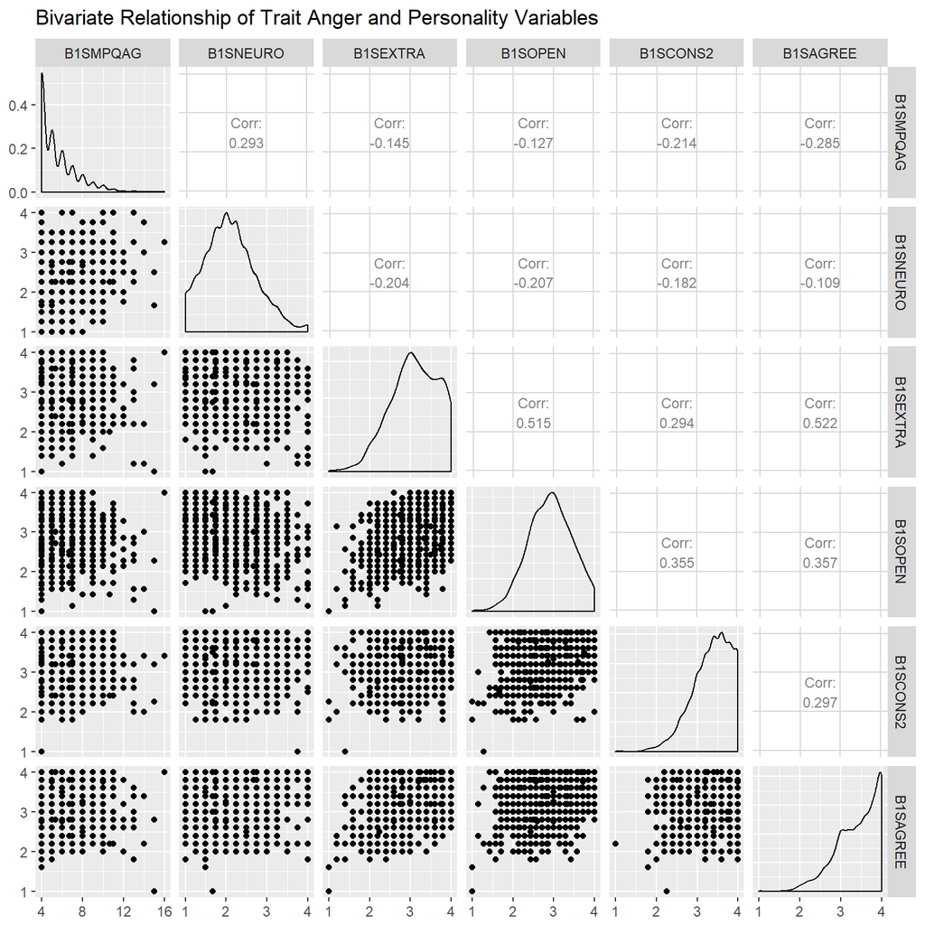

```r
scatterplot <- ggpairs(analyze,
                       columns = c("B1SMPQAG", "B1SNEURO", "B1SEXTRA", "B1SOPEN", "B1SCONS2", "B1SAGREE"),
                       upper = list(continuous = wrap("cor", size=3)),
        title = "Bivariate Relationship of Trait Anger and Personality Variables")
print(scatterplot, progress=FALSE )
```

## Hone in on aggression and one of the personality variables

I am going to select neuroticism, first I will subset to include only cases with complete data on my two variables of interest

```r
myvars <- analyze %>%
  select(B1SMPQAG, B1SNEURO) %>%
  na.omit()
```

## Descriptive statistics

### Aggression

```r
summary_stats(myvars$B1SMPQAG)
```

```
##                         Univariate Analysis
##
##  N                     1761.00      Variance                 3.37
##  Missing                  0.00      Std Deviation            1.84
##  Mean                     5.49      Range                   12.00
##  Median                   5.00      Interquartile Range      2.00
##  Mode                     4.00      Uncorrected SS       58939.46
##  Trimmed Mean             5.28      Corrected SS          5938.36
##  Skewness                 1.60      Coeff Variation         33.48
##  Kurtosis                 2.98      Std Error Mean           0.04
##
##                               Quantiles
##
##               Quantile                            Value
##
##              Max                                  16.00
##              99%                                  11.00
##              95%                                   8.00
##              90%                                   9.00
##              Q3                                    6.00
##              Median                                5.00
##              Q1                                    4.00
##              10%                                   4.00
##              5%                                    4.00
##              1%                                    4.00
##              Min                                   4.00
##
##                             Extreme Values
##
##                 Low                                High
##
##   Obs                        Value       Obs                        Value
##    1                           4         409                         16
##    3                           4        1142                         15
##    8                           4        1630                         15
##   11                           4         493                         14
##   17                           4        1103                         14
```

### Neuroticism

```r
summary_stats(myvars$B1SNEURO)
```

```
##                         Univariate Analysis
##
##  N                     1761.00      Variance                 0.40
##  Missing                  0.00      Std Deviation            0.63
##  Mean                     2.09      Range                    3.00
##  Median                   2.00      Interquartile Range      0.75
##  Mode                     2.00      Uncorrected SS        8429.00
##  Trimmed Mean             2.08      Corrected SS           702.54
##  Skewness                 0.44      Coeff Variation         30.16
##  Kurtosis                 0.03      Std Error Mean           0.02
##
##                               Quantiles
##
##               Quantile                            Value
##
##              Max                                   4.00
##              99%                                   3.85
##              95%                                   3.00
##              90%                                   3.25
##              Q3                                    2.50
##              Median                                2.00
##              Q1                                    1.75
##              10%                                   1.25
##              5%                                    1.00
##              1%                                    1.00
##              Min                                   1.00
##
##                             Extreme Values
##
##                 Low                                High
##
##   Obs                        Value       Obs                        Value
##   19                           1         96                           4
##   29                           1         295                          4
##   84                           1         300                          4
##   104                          1         416                          4
##   133                          1         502                          4
```

## Set hypotheses

I am interested in assessing the relationship between neuroticism and aggression. In this case, I am not particularly interested in a significance test for the intercept, it’s the slope that is of interest. I will state a null and alternative hypothesis for the slope.

My null hypothesis: B1 (the regression slope) is equal to 0  
My alterntive hypothesis: B1 is not equal to 0

## Set alpha and obtain the critical value of t

I am going to set alpha to .05, and use a 2 tailed test. For a SLR, the df equals n - 1 - # of predictors, so n-2, or 1761 - 2 = 1759 for my case.

```r
qt(c(.025, .975), df=1759)
```

```
## [1] -1.961314  1.961314
```

The critical value of t for this model is 1.961. If t-star is either greater than 1.961 or less than -1.961 then I will reject the null hypothesis.

## Center neuroticism at the mean and then fit the SLR

From the descriptive statistics above, we see that neuroticim ranges from 1 to 4, so 0 isn’t an observed value for this variable. Since the intercept of our SLR will represent the predicted value of y, when x equals 0, we should create a meaningful value of 0 for x. To do this, I will center at the mean.

```r
myvars <- myvars %>%
  mutate(B1SNEURO_m = B1SNEURO - mean(B1SNEURO))

my_model <- lm(B1SMPQAG ~ B1SNEURO_m, data = myvars)

ols_regress(my_model)
```

```
##                         Model Summary
## --------------------------------------------------------------
## R                       0.293       RMSE                1.757
## R-Squared               0.086       Coef. Var          32.023
## Adj. R-Squared          0.085       MSE                 3.086
## Pred R-Squared          0.083       MAE                 1.335
## --------------------------------------------------------------
##  RMSE: Root Mean Square Error
##  MSE: Mean Square Error
##  MAE: Mean Absolute Error
##
##                                  ANOVA
## -----------------------------------------------------------------------
##                 Sum of
##                Squares          DF    Mean Square       F         Sig.
## -----------------------------------------------------------------------
## Regression     509.560           1        509.560    165.104    0.0000
## Residual      5428.800        1759          3.086
## Total         5938.360        1760
## -----------------------------------------------------------------------
##
##                                  Parameter Estimates
## --------------------------------------------------------------------------------------
##       model     Beta    Std. Error    Std. Beta       t        Sig     lower    upper
## --------------------------------------------------------------------------------------
## (Intercept)    5.486         0.042                 131.046    0.000    5.404    5.568
##  B1SNEURO_m    0.852         0.066        0.293     12.849    0.000    0.722    0.982
## --------------------------------------------------------------------------------------
```

The intercept is 5.486, this is the predicted aggression score for individuals with an average level of neuroticim. The slope is .852, this is the expected change in aggression for a one unit increase in neuroticism.

The estimate of the slope divided by the associated standard error gives t-star, that is t-star = .852/.066 = 12.849. This means that our estimate of the slope is 12.849 standard errors away from the asserted null hypothesis (0). If the null hypothesis were true, we would expect about 95% of the random samples to produce an estimate of the slope that is within 1.96 standard errors of 0. Therefore it is highly unlikely that the null hypothesis is true given this estimate of the slope. In fact, the p-value is less than .001, which provides the probability that we would obtain a t-star of this magnitude or larger if the null hypothesis were true. Therefore, we reject the null hypothesis.

The 95% CI is .722 to .982. Based on the sampling distribution, we expect that 95% of the 95% CI’s that we would construct across many, many random samples would contain the population slope. We can think of the 95% CI as giving us a range of plausible values for the parameter estimate and showing us the precision of our estimate. The fact that 0 is not inside the 95% CI corresponds with our t-test, that is, 0 is not likely to be a plausile value for the slope.

In sum, it appears that neuroticism is significantly associated with aggression, higher scores on neuroticim are associated with higher scores on aggression. Neuroticim predicts 8.6% of the variance in aggression (see R-squared). In a SLR, the standardized beta is equal to the correlation, so the correlation between neuroticim and aggression is .29.

## Calculate predicted scores

I will request the predicted y when x is 1 SD below the mean, at the mean, and 1 SD above the mean in the sample. I will ask for both a 95% confidence interval and a 95% prediction interval around these predicted values.

```r
# pick a few prototypical values
predgrid <- data_grid(myvars, B1SNEURO_m = c(-.63, 0, .63))
predict(my_model, predgrid, interval = "confidence", level = .95)
```

```
##        fit      lwr      upr
## 1 4.949549 4.833580 5.065519
## 2 5.486088 5.403980 5.568196
## 3 6.022627 5.906657 6.138596
```

```r
predict(my_model, predgrid, interval = "prediction", level = .95)
```

```
##        fit      lwr      upr
## 1 4.949549 1.501989 8.397110
## 2 5.486088 2.039500 8.932676
## 3 6.022627 2.575066 9.470187
```

Notice that the 95% CI for the prediction interval is much wider to account for the fact that this is a prediction interval for a single new y – not for the mean of y. Also notice that the fitted value and 95% confidence interval for x = 0 is the same as the estimate of the intercept and the 95% CI for the intercept in the regression model. These are two ways of testing the same quantity.

## Create scatterplot of neuroticim and aggression with fitted model

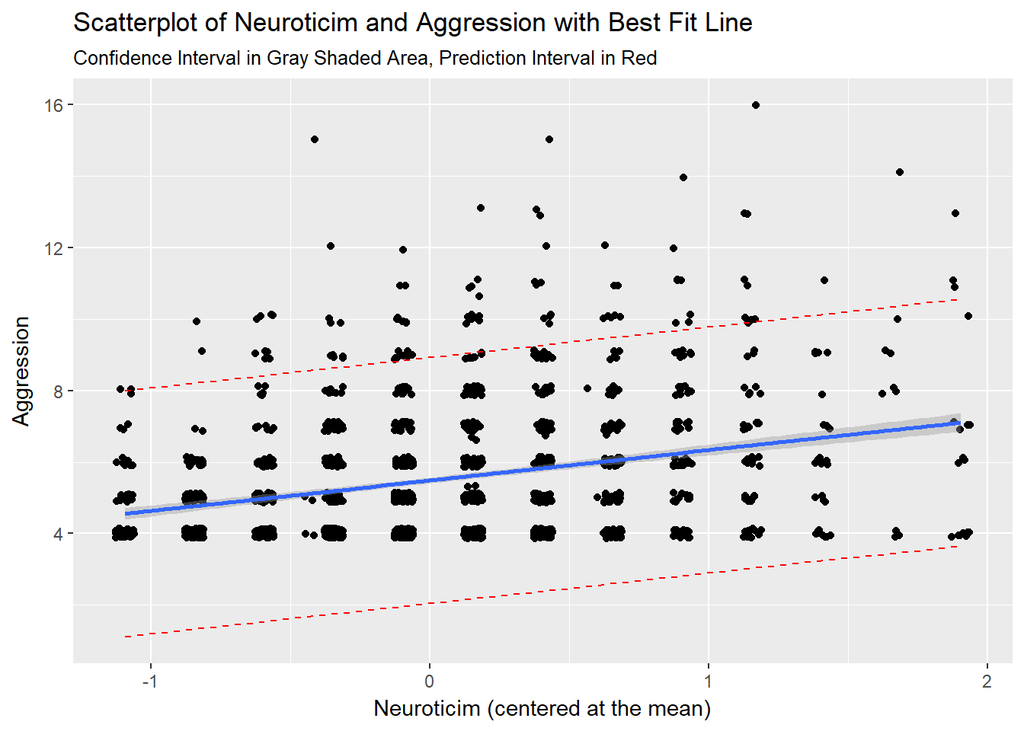

```r
# first get the prediction intervals for all cases in the dataset
temp_var <- predict(my_model, myvars, interval="prediction")
myvars_new <- cbind(temp_var, myvars)


ggplot(myvars_new, aes(x = B1SNEURO_m, y =B1SMPQAG)) +
  geom_jitter() +
  geom_smooth(method = "lm", se = TRUE) +
  geom_line(aes(y=lwr), color = "red", linetype = "dashed") +
  geom_line(aes(y=upr), color = "red", linetype = "dashed") +
  labs(title = "Scatterplot of Neuroticim and Aggression with Best Fit Line",
       subtitle = "Confidence Interval in Gray Shaded Area, Prediction Interval in Red",
       x = "Neuroticim (centered at the mean)", y = "Aggression")
```

Notice that I changed geom_point to geom_jitter. There are many points at the low end of the scale for both aggression and neurotocism, and without the jitter, these points are on top of one another and you cannot visually see this feature of the data. The problem of our skewed distribution for both variables is apparent in this graph – the expected distribution of y scores in each tail is not achieved. The result is non-normally distributed residuals. This violates the assumption of the linear regression model. We’ll discuss ways of dealing with this issue in Unit 8.

## Create graph of residuals

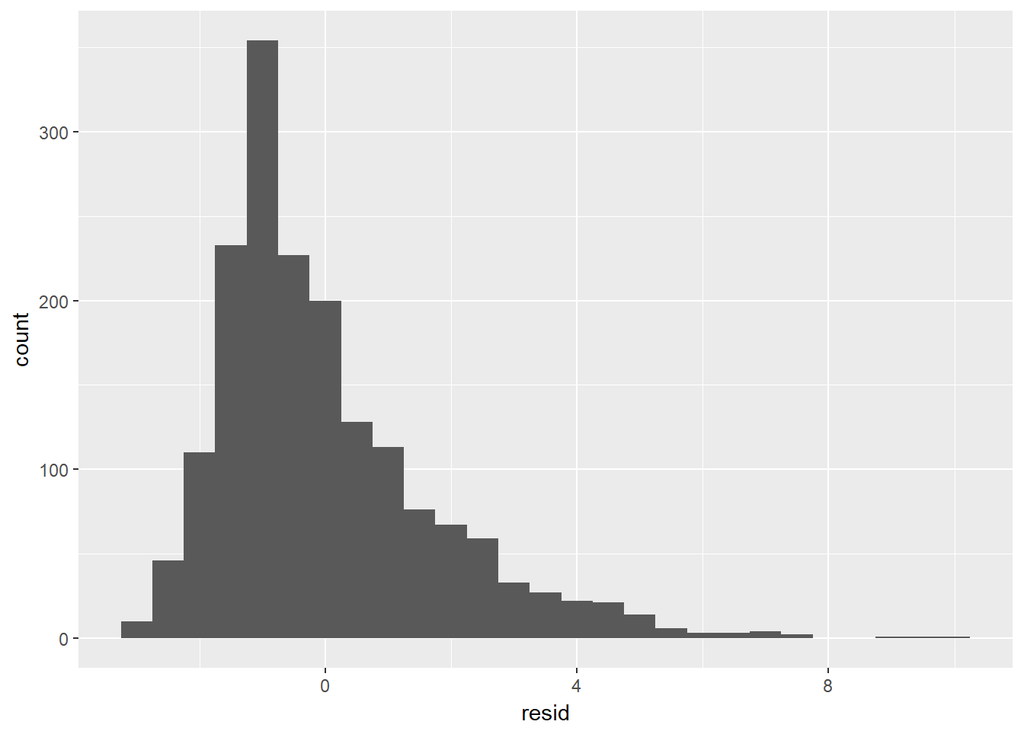

```r
myvars <- myvars %>%
  add_residuals(my_model)

ggplot(myvars, aes(x = resid)) + geom_histogram(binwidth = .5)
```